# Regresión en series de tiempo

Eduardo Aguilar, UCA

## Prediciendo ventas de autos en USA

**Este caso está basado en el curso de regresión aplicada de Columbia Business School. Puede encontrar la solución original en el archivo [Auto Sales Fall 2017](http://www.columbia.edu/~dj114/8114projects.htm). Las modificaciones y soluciones alternativas son responsabilidad de Eduardo Aguilar.**

## El contexto de negocios

La industria automovilística puede indicar el estado y dirección de la economía estadounidense. Después de los gastos en vivienda, los autos son los productos en los que más puede gastar un consumidor promedio. Las ventas de autos son un aproximado de la confianza del consumidor.

Debido a su nivel de relevancia en la economía norteamericana, no sería absurdo suponer que las ventas de autos pueden estar siendo ..influenciadas por factores macroeconómicos como el producto interno bruto y la tasa de desempleo, así como factores propios de la industria automovilística.

Una empresa que se dedica a fabricar accesorios para autos está interesada en saber cual es el mercado potencial que tendrán el próximo año. El departamento de finanzas hace sus proyecciones basados en el número de autos que se estima vender en el país, y hasta ese momento habían estado usando las ventas del último período anterior como la mejor aproximación a las ventas del siguiente período. Este año decidieron cambiar de estrategia encargando al departamento de analítica el diseño de una herramienta que les ayudara a determinar cuál sería el mercado.

## Los datos

La tabla que se presente fue diseñada tomando datos de varias fuentes, incluyendo al [Buró de Análisis Económico](https://www.bea.gov/), al [Departamento de Energía](https://www.energy.gov/), el sistema de información financiera [Bloomberg](https://www.bloomberg.com/), entre otros.

**Variables Independientes**

| Nombre | Descripción | Fuente |
| --- | --- | --- |
| New Auto Sales | Ventas de Carros | [Ward’s Autos](https://www.wardsauto.com) |
| New Truck Sales | Ventas de Camiones | [Ward’s Autos](https://www.wardsauto.com) |
| Total | Ventas Totales | [Ward’s Autos](https://www.wardsauto.com) |

**Variables de la industria automotriz**

| Nombre | Descripción | Fuente |
| --- | --- | --- |
| Auto Inventories | Inventarios | [Buró de Análisis Económico](https://www.bea.gov/) |
| New Vehicle Price Inflation | Inflación en Autos Nuevos | [Buró Estadísticas Laborales](https://www.bls.gov) |
| Used Vehicle Price Inflation | Inflación en Autos Viejos | [Buró Estadísticas Laborales](https://www.bls.gov) |
| Gas Prices | Precio de Petróleo | [Departamento de Energía](https://www.energy.gov/) |
| Consumer Confidence: Automobiles | Confianza Consumidor | [Conference Board](https://www.conference-board.org/us/) |
| Miles Driven | Millas Manejadas | [Dpt de Transporte](https://www.transportation.gov/) |
| New Car Interest Rate | Tasa de interés para Carros | [Reserva Federal](https://www.wardsauto.com) |

**Variables macroeconómicas y financieras**

| Nombre | Descripción | Fuente |
| --- | --- | --- |
| US Population | Población USA | [Buró de Análisis Económico](https://www.bea.gov/) |
| Unemployment Rate | Tasa de Desempleo | [Bloomberg](https://www.bloomberg.com/) |
| Disposible Income | Ingresos Disponibles | [Buró de Análisis Económico](https://www.bea.gov/) |
| Household Savings | Ahorros de Hogares | [Buró de Análisis Económico](https://www.bea.gov/) |
| House Price Inflation | Inflación Precios de Casas | [Bloomberg](https://www.bloomberg.com/) |
| Consumer Confidence | Confianza del consumidor | [Conference Board](https://www.conference-board.org/us/) |
| GDP (Real) | PIB Real | [Buró de Análisis Económico](https://www.bea.gov/) |
| Fed Funds Rate | Tasa de la Reserva Federal | [Reserva Federal](https://www.federalreserve.gov/) |
| Inflation | Inflación | [Buró Estadísticas Laborales](https://www.bls.gov) |
| Non Farm Payrolls | Salarios sin Agricultura | [Buró Estadísticas Laborales](https://www.bls.gov) |

Leyendo los datos:

|  | 01 | 02 | 03 | 04 | 05 |
| --- | --- | --- | --- | --- | --- |
| ï..Date | 31/3/1994 | 30/4/1994 | 31/5/1994 | 30/6/1994 | 31/7/1994 |
| Car | 876487 | 787201 | 816102 | 870757 | 713421 |
| Truck | 572605 | 525248 | 542678 | 577002 | 478797 |
| Total | 1444671 | 1312449 | 1358780 | 1447759 | 1192218 |
| Time | 1 | 2 | 3 | 4 | 5 |
| Year | 1 | 1 | 1 | 1 | 1 |
| Q1 | 1 | 0 | 0 | 0 | 0 |
| Q2 | 0 | 1 | 1 | 1 | 0 |
| Q3 | 0 | 0 | 0 | 0 | 1 |
| Inventories | 1381.0 | 1343.4 | 1383.6 | 1416.0 | 1454.6 |
| CPI_New_Cars | 3.361345 | 3.279939 | 3.351104 | 3.664122 | 3.743316 |
| CPI_Used_Cars | 5.529226 | 5.128205 | 4.866920 | 4.914371 | 4.775900 |
| Gas_Prices | 1.012 | 1.037 | 1.050 | 1.095 | 1.114 |
| Cons_Conf_Autos | 5.8 | 7.1 | 6.6 | 5.0 | 8.5 |
| Miles_Driven | 196190 | 195407 | 206594 | 207280 | 214778 |
| Bank_Auto_Interest_Rate | 7.54 | 7.54 | 7.76 | 7.76 | 7.76 |
| US_Population_millions | 262.4853 | 262.7577 | 263.0117 | 263.2929 | 263.5779 |
| Unemployment | 6.57 | 6.57 | 6.57 | 6.20 | 6.20 |
| Disposible_Income_Capita_Real | 26403 | 26384 | 26676 | 26597 | 26591 |
| Saving_Capital | 1636.986 | 1530.272 | 1893.996 | 1675.611 | 1701.824 |
| Household_Debt_Capital | 22017.46 | 22001.62 | 22245.12 | 22205.84 | 22200.83 |
| US_House_Price_Inflation | 3.259811 | 3.259811 | 3.259811 | 2.911299 | 2.911299 |
| Consumer_Confidence | 86.73 | 92.07 | 88.91 | 92.52 | 91.30 |
| RealGDP | 37138.08 | 37099.57 | 37063.75 | 37530.07 | 37489.49 |
| Fed_Funds_Rate | 3.34 | 3.56 | 4.01 | 4.25 | 4.26 |
| US_Urban_CPI_Change | 2.5 | 2.4 | 2.3 | 2.5 | 2.8 |
| Nonfarm_Payrolls | 16799 | 16855 | 16932 | 17103 | 16991 |

Existen 5 variables extras que fueron creadas: Time, Year, Q1, Q2, Q3. En breve explicaremos porque se diseñaron estas variables.

## Exploración de Datos

### Tendencias a través del tiempo

En las series temporales, como su nombre lo dice, el tiempo es un factor importante, ya que este puede determinar el status de una variable. En los precios de las acciones, por ejemplo, se pueden observar períodos en los que el precio de la acción cotiza a la baja; mientras que en las ventas minoristas es natural ver temporadas en que se vende mucho o vende poco (pre y post navidad).

Entonces, lo primero que se hará es visualizar la tendencia de precios a lo largo del tiempo.

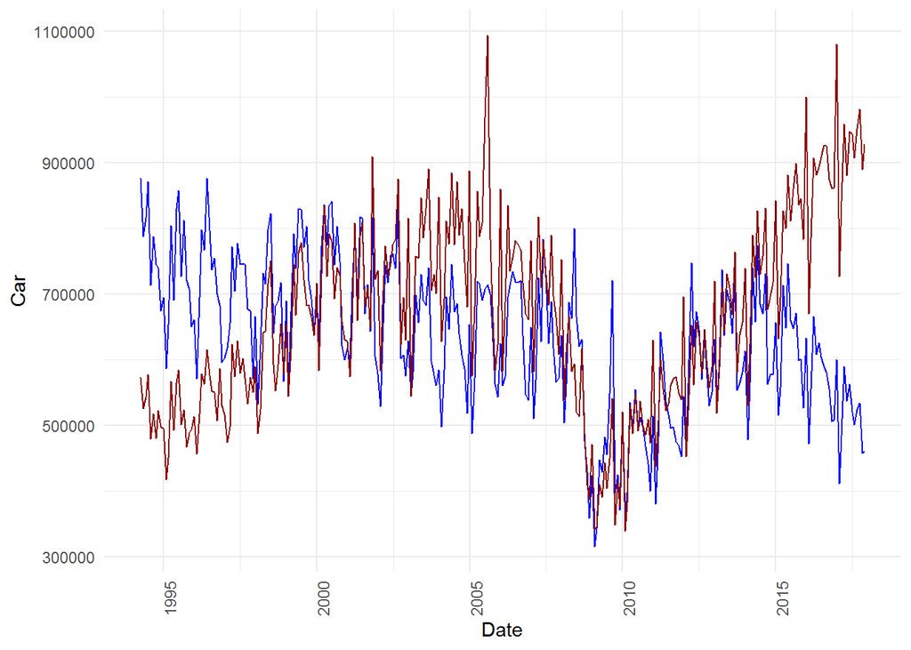

Ahora bien, parecen haber pocas anormalidades en el número de camiones vendidos con un pico en finales de 2005, y dos claras tendencias de declive a partir del año 2007 y de incremento continuado desde el año 2009.

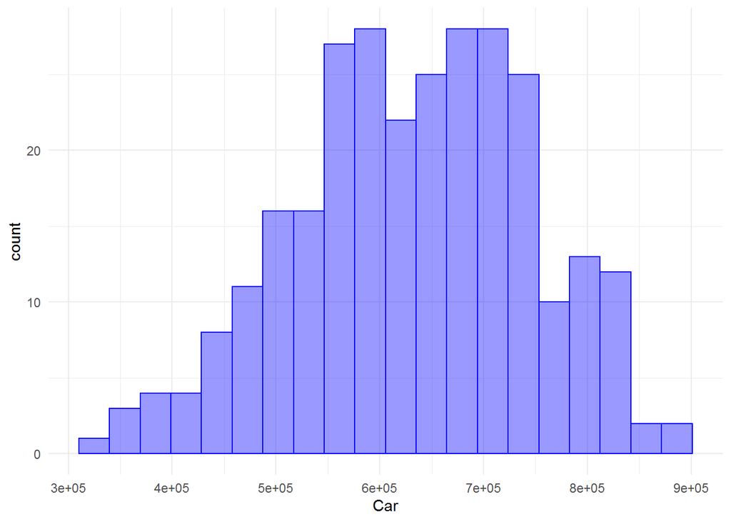

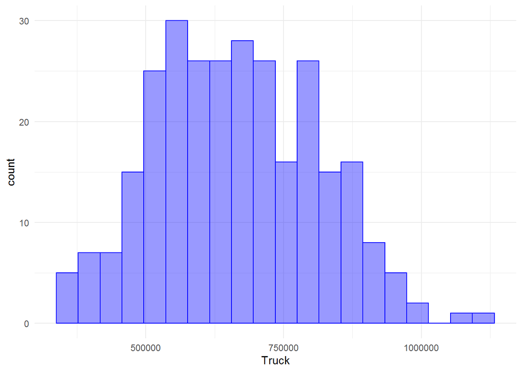

En efecto, no parece haber nada anormal con los datos. Si usted tuviera un dato anormalmente grande/pequeño, no debería incluirlo en el análisis (o incluirlo pero no con su valor original) porque los métodos probabilísticos como la regresión lineal no son lo suficientemente robustos para asumir este tipo de cambios bruscos sin verse afectados en su eficiencia.

### Diagramas de dispersión

Tenemos 18 variables independientes de naturaleza macroeconómica o de la industria automotriz, de las cuales debemos entender cuales tienen relaciones aproximadamente lineales respecto al número de autos o camiones vendidos.

#### Autos

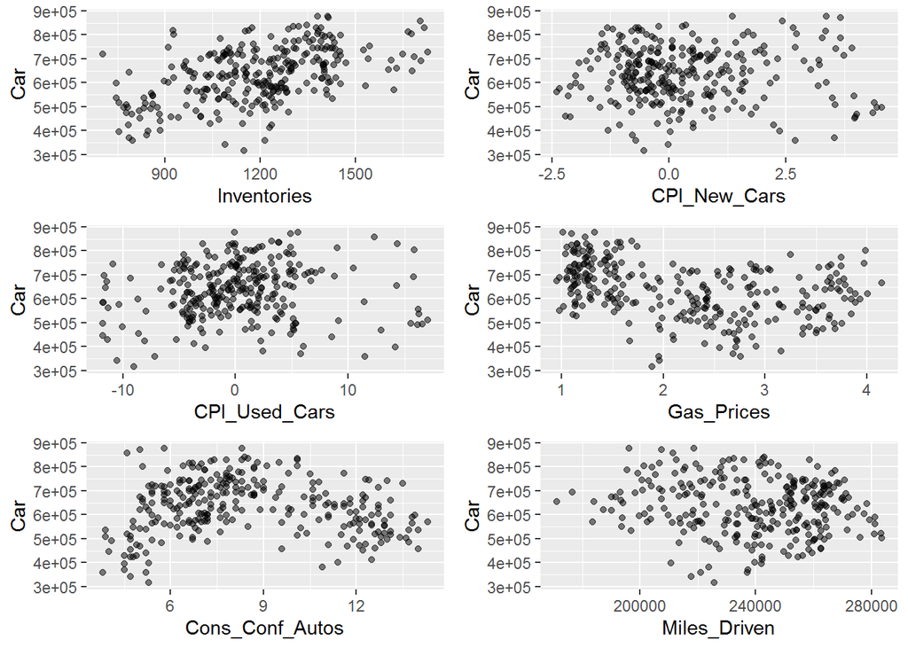

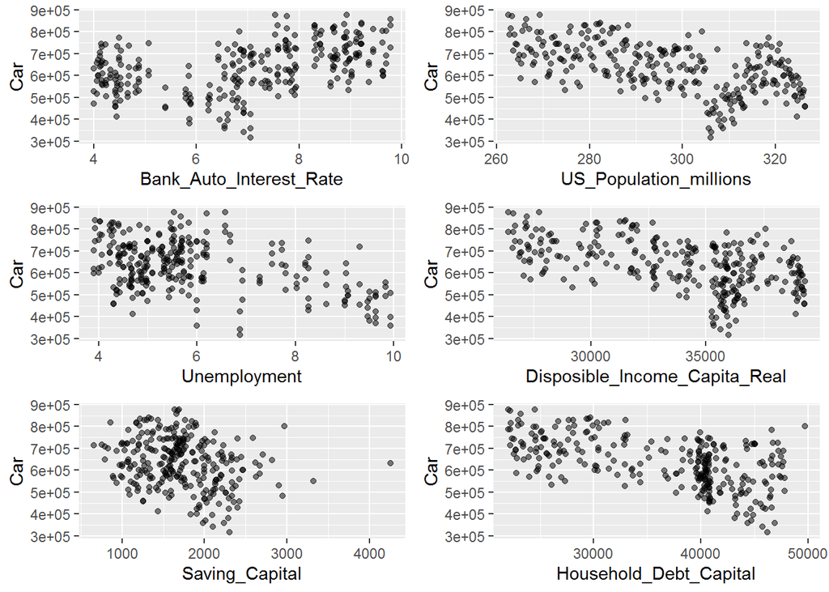

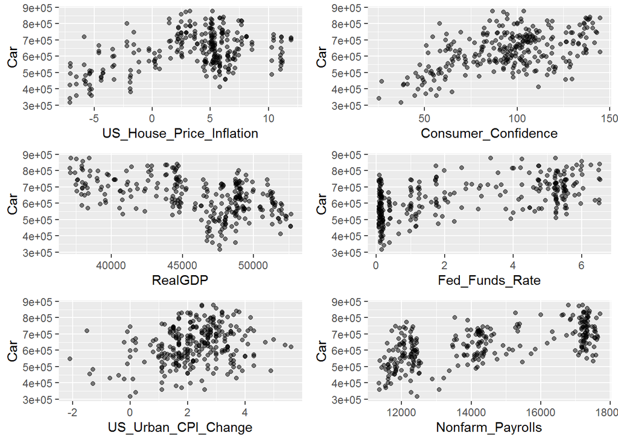

Bien, de los gráficos anteriores podemos inferir que variables tienen correlaciones aproximadamente lineales con nuestros datos. Este proceso de exploración puede también ser efectuado sacando las correlaciones entre variables (esto último lo puede hacer en excel o en R, pero si son demasiados datos excel tronará). Las variables que parecen relevantes son: Inventories, CPI_Used_Cars, US_Population_millions, Unemployment,Disposible_Income_Capita_Real, Household_Debt_Capital, Consumer_Confidence, RealGDP, Fed_Funds_Rate, Nonfarm_Payrolls.

#### Camiones

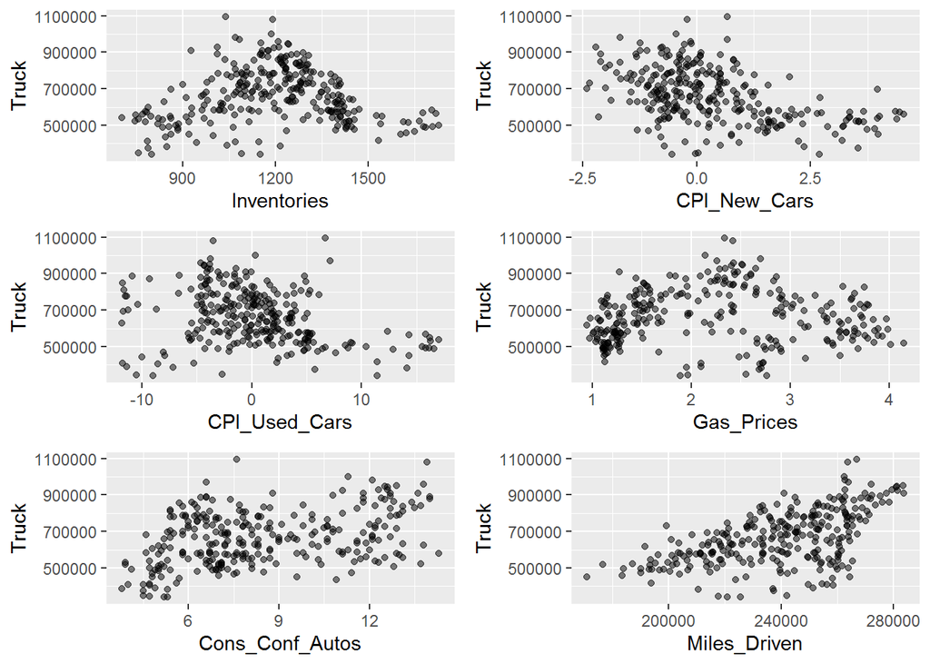

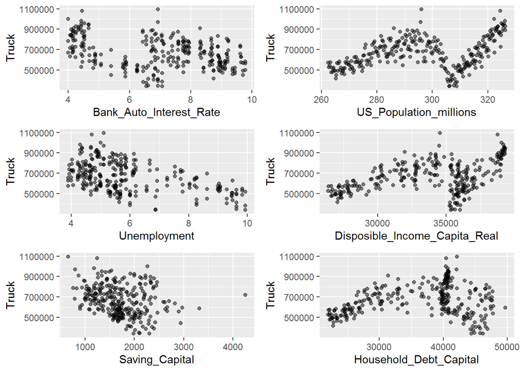

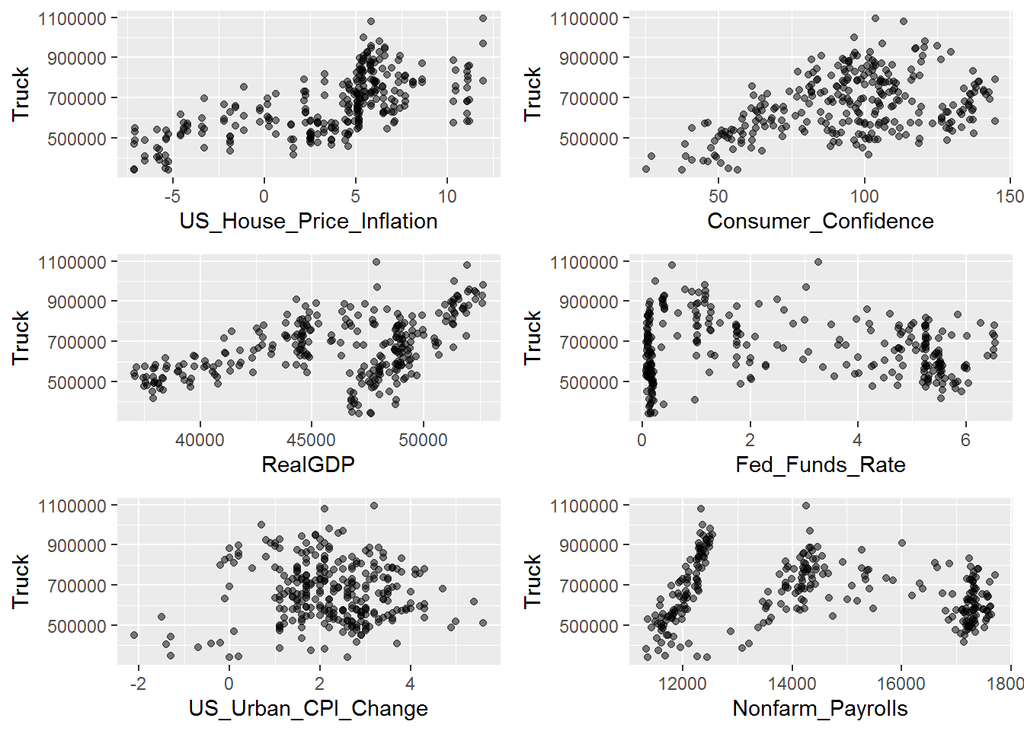

En el caso de los camiones, las variables relevantes serían: CPI Carros Nuevos, Millas Manejadas (Miles Driven), Desempleo, Precios de Hogares, PIB (GDP). Entonces, a partir de esos gráficos que ve que las variables explicativas difieren entre los dos tipos de vehículos, así que se vuelve sensato diseñar diferentes modelos.

## Separando datos

Los pronósticos en series de tiempo tienen una diferencia fundamental respecto a las series no temporales, y sí, como su nombre lo dice esa diferencia es el tiempo. Suponga que usted trabaja para una gestora de fondos de inversión, tiene 1,000 días de historia de los precios de las acciones y otros factores financieros, toma una muestra aleatoria de 800 días para construir un modelo e intenta predecir los restantes 200 días. ¿Cuál es el problema con este enfoque?

Cómo habrá notado, el problema con este tipo de muestras aleatorias es que estaría utilizando información futura para predecir precios del pasado, entonces es posible que el modelo funcionara bien en el entrenamiento y validación, pero no tendría resultados consistentes en la práctica. Para que los resultados teóricos y reales sean similares usted debe intentar representar la realidad lo mejor posible, es decir, entrenando con datos pasados y evaluando con datos futuros. Esto se logra eligiendo una fecha que divida dos ventanas de tiempo, la de entrenamiento y la de validación.

La siguiente imagen muestra como se haría la validación en varias capas, pero por simplicidad nosotros solo tomaremos la última capa para evaluar el desempeño.

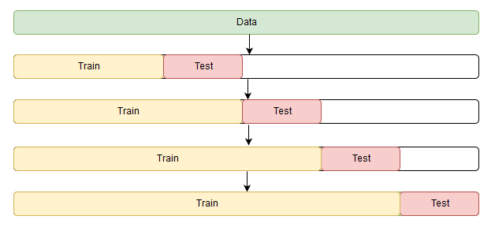

**Validacion en 4 capas**

Dicho de otro modo, nosotros entrenaremos con datos pasados a una fecha límite, y evaluaremos resultados con datos futuros a la misma fecha:

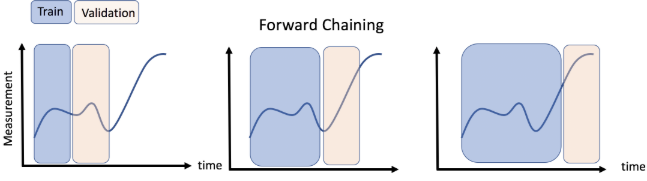

**Validacion en serie de tiempo**

Nosotros estamos interesados en predecir un año a futuro, así que nuestros datos de entrenamiento serán de 1994 hasta 2016, mientras que nuestros datos de evaluación serán solo de 2017.

## Autos

Vamos a construir varios modelos y seleccionaremos el que funcione mejor. Nuevamente, eso puede sonar a que estamos haciendo prueba y error, pero en efecto esto así es, usted raramente encontrará el mejor modelo a la primera iteración. Tampoco encontraremos el mejor modelo en esta sesión, pero pretenedemos acercarnos a una solución subóptima que sea mejor que una solución aleatoria.

### Modelo 1: Regresión Lineal

Comencemos por incluir todas las variables posibles y todos los datos de entrenamiento desde 1994 hasta 2016. Estos son los resultados del modelo:

|  | Estimate | Std. Error | t value | Pr(>\|t\|) |
| --- | --- | --- | --- | --- |
| (Intercept) | -3.964767e+05 | 3.471717e+06 | -0.1142019 | 0.9091694 |
| Time | 2.577745e+04 | 4.367599e+03 | 5.9019726 | 0.0000000 |
| Year | -3.581318e+05 | 4.291771e+04 | -8.3446155 | 0.0000000 |
| Q1 | 3.294287e+05 | 3.305970e+04 | 9.9646610 | 0.0000000 |
| Q2 | 2.275067e+05 | 2.336877e+04 | 9.7355049 | 0.0000000 |
| Q3 | 9.772001e+04 | 1.398711e+04 | 6.9864341 | 0.0000000 |
| Inventories | 2.731521e+01 | 3.499631e+01 | 0.7805170 | 0.4358250 |
| CPI_New_Cars | -2.242594e+03 | 3.709176e+03 | -0.6046072 | 0.5459884 |
| CPI_Used_Cars | 2.385080e+03 | 7.465411e+02 | 3.1948410 | 0.0015789 |
| Gas_Prices | 1.138009e+05 | 1.281219e+04 | 8.8822374 | 0.0000000 |
| Cons_Conf_Autos | -1.790993e+03 | 2.653043e+03 | -0.6750714 | 0.5002543 |
| Miles_Driven | 3.224867e+00 | 2.820505e-01 | 11.4336529 | 0.0000000 |
| Bank_Auto_Interest_Rate | -4.008267e+04 | 1.285502e+04 | -3.1180557 | 0.0020336 |
| US_Population_millions | 5.288793e+03 | 1.592616e+04 | 0.3320822 | 0.7401054 |
| Unemployment | -3.578826e+04 | 1.602324e+04 | -2.2335216 | 0.0263997 |
| Disposible_Income_Capita_Real | 9.771366e+01 | 1.885050e+01 | 5.1836098 | 0.0000004 |
| Saving_Capital | -8.757538e+01 | 1.953683e+01 | -4.4825779 | 0.0000112 |
| Household_Debt_Capital | -1.564643e+01 | 3.895591e+00 | -4.0164465 | 0.0000782 |
| US_House_Price_Inflation | -1.054036e+03 | 1.499202e+03 | -0.7030647 | 0.4826696 |
| Consumer_Confidence | 3.505675e+02 | 3.910843e+02 | 0.8963987 | 0.3709022 |
| RealGDP | -6.193234e+01 | 1.644519e+01 | -3.7659844 | 0.0002069 |
| Fed_Funds_Rate | 9.898430e+03 | 8.606177e+03 | 1.1501542 | 0.2511794 |
| US_Urban_CPI_Change | -1.837623e+04 | 4.990076e+03 | -3.6825543 | 0.0002830 |
| Nonfarm_Payrolls | -1.337754e+01 | 2.979330e+01 | -0.4490119 | 0.6538120 |

Aunque la mayoría de valores p son cercanos a cero, el modelo incluye algunas variables que no son estadísticamente significativas, lo cual es indicio que debemos reducir el número de variables. Veamos ahora cual es el Mean Square Error en los conjuntos de entrenamiento y validación:

```
## [1] "Train Error:  33583.2594288441"
```

```
## [1] "Test Error:  100200.036726535"
```

Que la diferencia sea tan grande indica que el modelo está terriblemente sobreajustado a los datos de entrenamiento. Debemos entonces reducir este sobreajuste, para lo cual crearemos más modelos. Hay dos formas de reducirlo: limitando el número de variables; y en series de tiempo, limitando la ventana de entrenamiento.

### Modelo 2: Reduciendo ventana de entrenamiento

Un detalle en particular con las series de tiempo es que las relaciones son dinámicas y las tendencias cambian a lo largo de los años: hay crisis y buenos tiempos. En ese sentido debemos limitar la ventana temporal de entrenamiento, pues no siempre se encontrarán las mismas características. Analizando la historia, recordemos que tuvimos dos períodos de crisis en los úlimos 20 años, la burbuja **.com** en 2000-2001 y la crisis hipotecaria del 2008, cuyo impacto duró hasta medidados de 2009 (y sus efectos pueden verse reflejados en una de las gráficas anteriores). Definamos entonces, un período de entrenamiento desde un año “X” hasta 2016 y uno de evaluación del año 2017 entrenando nuevamente el modelo con todas las variables.

```
## [1] "Train Error:  25090.8719383016"
```

```
## [1] "Test Error:  69376.4349203936"
```

Y mágicamente nuestro error se redujo en ambos conjuntos, entrenamiento y evaluación.

- ¿Puede usted imaginar que año se utilizó para este cálculo?
- ¿Pruebe con varias opciones para “X”, porqué los resultados son tan similares o tan diferentes?

Por otro lado, estos dos siguen aún siendo muy diferentes, lo que da indicios que aún podemos mejorar.

### Modelo 3: Utilizando la exploración visual.

Ahora bien, recordemos que en la fase de exploración habíamos seleccionado un conjunto de variables que tenían potencial de ser significativas dada su fuerte correlación con la variable objetivo. Podemos intentar reducir el número de variables manualmente para ver que sucede con el error. Podemos primero seleccionar las variables de tiempo **Time, Year, Q1, Q2, Q3**. Luego las variables de la exploración visual. Usted puede iniciar probando con las variables encontradas en la exploración visual y luego añadir/remover variables dependiendo del desempeño del error de evaluación. En nuestro caso, después de intentar con prueba y error se encontraron las siguientes: **CPI_Used_Cars, Gas_Prices, Miles_Driven, US_Population_millions, Unemployment, Disposible_Income_Capita_Real, Saving_Capital, Household_Debt_Capital, RealGDP, Fed_Funds_Rate, US_Urban_CPI_Change, Nonfarm_Payrolls**.

```
## [1] "Train Error:  27471.4444488892"
```

```
## [1] "Test Error:  33678.6884282487"
```

Ahora hemos llegado a un punto donde tanto el error de entrenamiento como el error de evaluación son muy similares, pero aún tenemos una pequeña diferencia que puede ser mejorada, solo que en este caso parece muy difícil hacerlo de forma visual, y debemos recurrir a técnicas más avanzadas.

### Modelo 4: Limitando el número de variables (Regularizando)

Una técnica muy conocida para limitar el efecto de incluir demasiadas variables es Regularizando. La regularización reduce el efecto de incluir demasiadas variables en el modelo penalizando por cada variable extra. Los métodos más famosos son la Regresión Contraida (Ridge Regression) y Regresión Lasso. Al correr el modelo utilizando Lasso obtenemos los siguientes resultados:

```
## [1] "train set:  28428.4728750843"
```

```
## [1] "test set:  27127.5413996709"
```

En este caso, hemos logrado reducir el error de evaluación y aumentado el error del entrenamiento, haciendo que el desempeño de ambos sea muy cercano. Esto indica que hemos optimizado nuestro **modelo lineal** con estas variables predictivas (no necesariamente el mejor modelo). Esto se debe a que la regularización automáticamente eligió las variables con más poder predictivo. Pero tenga en cuenta que lo que en realidad redujo el error significativamente no fue la caja negra de la regularización, sino más bien la reducción de variables y la reducción de la ventana de entrenamiento que elegimos de forma visual, una vez hecho eso se procedió a optimizar el modelo con la regularización.

## Camiones

Repitamos el proceso para los camiones. Estos son los valores que yo encontré:

### Modelo 1: Datos completos

Usemos todas las variables en todos los períodos

```
## [1] "Train Error:  38008.9850274646"
```

```
## [1] "Test Error:  65098.270455496"
```

El modelo está sobreajustado. Tiene posibilidad de mejora

### Modelo 2: Reduciendo ventana de entrenamiento

```
## [1] "Train Error:  30471.4615268323"
```

```
## [1] "Test Error:  35259.5986614333"
```

Aún hay diferencia pero esta es pequeña, intentemos ahora seleccionar variables.

### Modelo 3: Reduciendo variables

Podemos ahora seleccionar en base a los diagramas de dispersión las variables que creamos pueden reduicir el error del modelo aún más.

```
## [1] "train set:  33172.6691927139"
```

```
## [1] "test set:  34058.7570215387"
```

Este modelo parece tener un buen ajuste ya que el error de entrenamiento y el de evaluación son muy parecidos. Parece muy difícil poder mejorarlo manualmente.

### Modelo 4: Regularizando

Apliquemos entonces regularización al modelo anterior

```
## [1] "train set:  33551.7103332015"
```

```
## [1] "test set:  27459.3625106085"
```

Sorpresivamente el error de evaluación es mucho menor que el error de entrenamiento. Pero no nos asustemos, esto no es un síntoma de un modelo con sobreajuste. ¿Puede usted imaginar que es?

Y recordemos como siempre, que usted no puede nunca dar por finalizado el proceso de modelación. Siempre pueden existir maneras de mejorar el análisis, pero debe saber reconocer cuando vale la pena invertir esfuerzos en ello.

> Analítica de datos es un proceso iterativo, podríamos necesitar regresar a nuestros datos originales en cualquier momento y seleccionar nuevos atributos, así como diferentes herramientas de regresión y modelamiento.